# Assignment 2: Summarizing and Visualizing Data

Modern Research Methods

**Objectives**

By the end of this assignment, you should:

- understand how to read in data using `read_csv`
- understand how to derive information from data (`summarize`, `mutate`, `group_by`)
- understand how to make and modify a basic plot using ggplot

This assignment is due **Thursday, September 23 at noon**. Please turn your .html AND .Rmd files into Canvas. Your .Rmd file should knit without an error before turning in the assignment.

To get started, you’ll need make a .Rmd document. You can start by using the template from the previous assignment and modifying it as appropriate (including title, name, etc). This assignment focuses on data from a recent paper examining the role that songs play in soothing infants ([Bainbridge & Bertolo et al., 2021](https://www.nature.com/articles/s41562-020-00963-z.pdf)). To get started, you should give the paper a read and broadly understand the question the paper is trying to answer and the methods that they used (note that the methods are described in detail at the *end* of the paper). Note that for all the questions requiring code, you should use tidyverse functions.

1. [a] What is the main question that the experiment is designed to address?  
   [b] What did the experimenters manipulate? (the independent variable)  
   [c] What are three variables the researchers measured? (the dependent variables)  
   [d] The authors consider an alternative hypothesis for their heart rate results. What is this hypothesis?

In this assignment, we’ll focus on the heart rate data. You can download a lightly cleaned version of their heart rate data here:

```r
bb2021 <- read_csv("https://raw.githubusercontent.com/mllewis/cumulative-science/master/static/data/bb_2021_hr_clean.csv")
```

(if you’re curious, you can explore all their raw data by going to the repository associated with the paper, [here](https://github.com/themusiclab/infant-relax/)).

```r
bb2021 %>%
  summarize(youngest = min(age),
            oldest = max(age),
            total = n())
```

3. Create a dataframe with only the first observation from the first trial for each participant. Uses this dataframe to answer the following questions:  
   [a] How many participants are present in the dataset?  
   [b] How many 7-month-olds are there?  
   [c] Arrange the dataframe from youngest to oldest. What’s the participant_id for the youngest infant?  
   [d] Arrange the dataframe from oldest to youngest. What’s the participant_id for the oldest infant?

[a]

```r
first_df <- bb2021 %>%
  filter(obs_num == 1, trial_id == 1)

nrow(first_df)
```

[b]

```r
first_df %>%
  group_by(age_cat) %>%
  summarize(n = n())
```

[c]

```r
first_df %>%
  arrange(age)
```

[d]

```r
first_df %>%
  arrange(-age)
```

4. What is the mean number of observations per trial? (hint: you’ll need to use both `group_by` and `ungroup`).

```r
bb2021 %>%
  group_by(participant_id, trial_id) %>%
  summarize(n = n()) %>%
  ungroup() %>%
  summarize(mean = mean(n))
```

4. How many observations are there in in the lullaby condition and the non-lullaby condition?

```r
bb2021 %>%
  group_by(trial_type) %>%
  summarize(n = n())
```

6. Next, let’s examine the dependent variable, heart rate. Create a new variable called `hr_round` that is the heart rate value rounded to the nearest hundredth (use the function `round()`).

```r
bb2021 <- bb2021 %>%
  mutate(hr_round = round(zhr_pt, 2))
```

5. Plot a histogram of `hr_round` using the geom, `geom_histogram`. Be sure to add an appropriate title to your plot.

```r
bb2021 %>%
  ggplot(aes(x = hr_round)) +
  geom_histogram() +
  ggtitle("Heart Rate Distribution")
```

5. Calculate the mean heart rate for each participant on each trial type. Save it to a new dataframe called `participant_means`.

```r
participant_means<- bb2021 %>%
  group_by(participant_id, trial_type) %>%
  summarize(mean = mean(hr_round))
```

6. Use `participant_means` to create a violin plot showing the distribution of heart rates in the lullaby and non-lullaby conditions. Your plot should be a simplified version of Figure 2a in the paper with (a) two violins, (b) each violin a different color, and (c) points showing the underlying data. (hint: the order that you add geoms to your plot matters!).

```r
ggplot(participant_means, aes(x = trial_type, y = mean, color = trial_type)) +
  geom_violin() +
  geom_point()
```

6. Use `participant_means` to calculate the overall means in the lullaby and non-lullaby conditions. Save this to a new dataframe called `condition_means`, and plot the two means as a bar plot of different colors. (hint: use `geom_bar(stat = "identity")`).

```r
condition_means <- paricipant_means %>%
  group_by(trial_type) %>%
  summarize(mean = mean(mean))

ggplot(condition_means, aes(x = trial_type, y = mean, fill = trial_type))  +
  geom_bar(stat = "identity")
```

7. Create the plot below showing the mean heart rate by condition across trials. For extra credit, change the point size such that it corresponds to the number of trials represented.

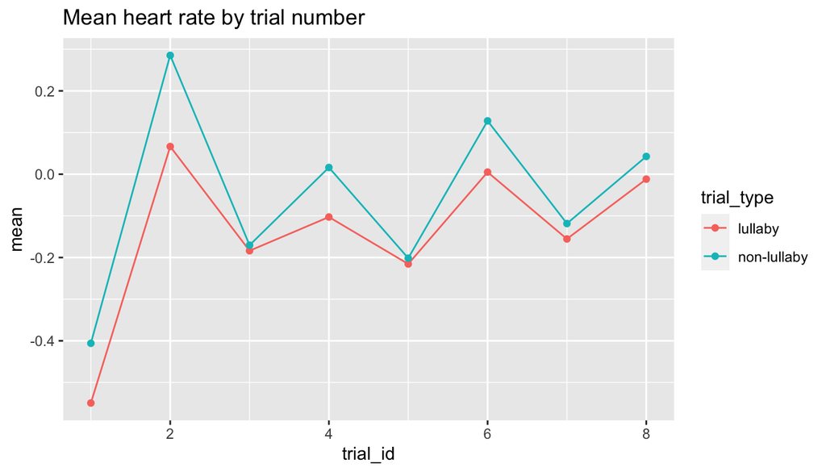

```r
trial_means <- bb2021 %>%
  group_by(trial_type, trial_id) %>%
  summarise(mean = mean(zhr_pt),
            n = n(),
            .groups = "keep")

ggplot(trial_means, aes(x = trial_id, y = mean, color = trial_type)) +
  geom_line() +
  geom_point() + #aes(size = n)
  ggtitle("Mean heart rate by trial number")
```

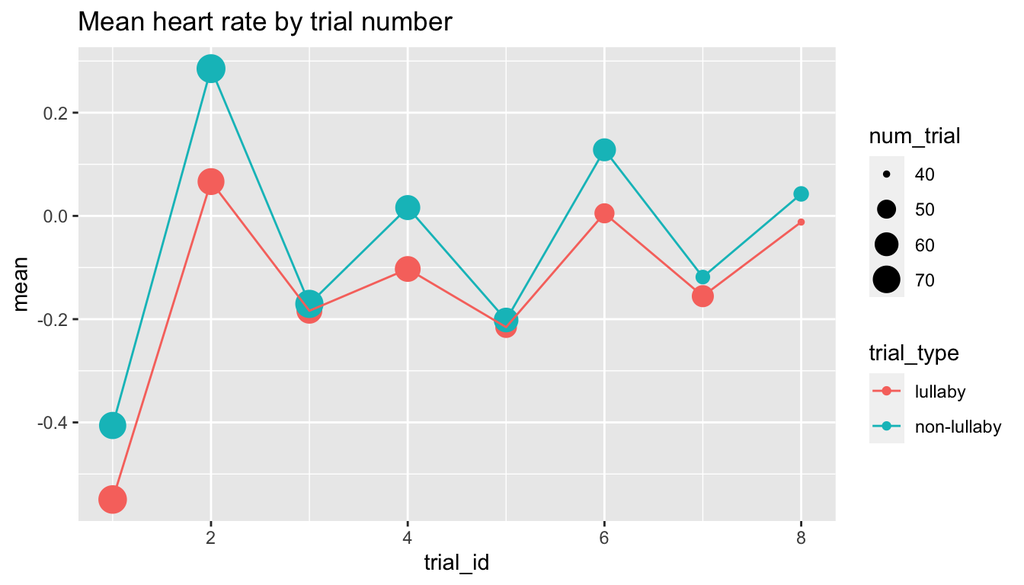

```r
# Jonathan
bb2021 %>%
  group_by(trial_type, trial_id) %>%
  summarize(hr_means = mean(zhr_pt), num_trial = n_distinct(participant_id)) %>%
  ggplot(mapping = aes(x = trial_id, y = hr_means, color = trial_type, size = num_trial)) +
  geom_point() +
  geom_line(size = 0.5) +
  ggtitle("Mean heart rate by trial number") +
  ylab("mean")
```

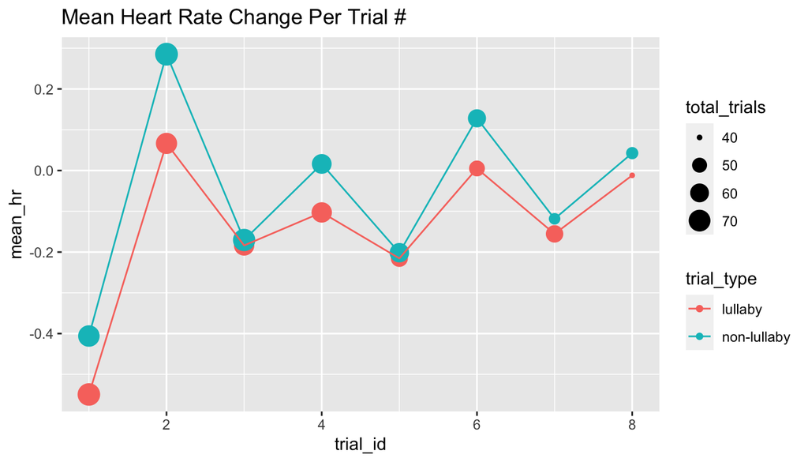

```r
# Nora
trial_means <- bb2021 %>%
  group_by(trial_id, trial_type) %>%
  summarize(mean_hr = mean(zhr_pt), total_trials = n_distinct(participant_id))

ggplot(trial_means, mapping = aes(x = trial_id, y = mean_hr, color = trial_type)) +
  geom_point(mapping = aes(size = total_trials)) +
  geom_line() +
  ggtitle("Mean Heart Rate Change Per Trial #")
```

1. Choose your own geom! Look at the geoms on the [ggplot cheatsheet](https://github.com/rstudio/cheatsheets/raw/master/data-visualization.pdf) and choose one to use with this data (other than geom_line, geom_point, geom_violin, and geom_bar). Make a beautiful, clear plot. *Make sure to include a descriptive title.*

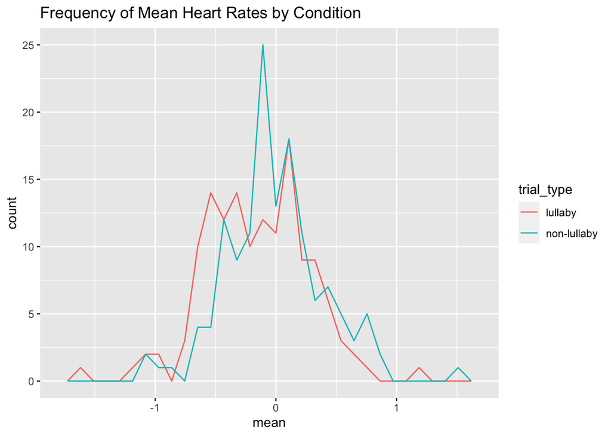

```r
# Emily (Visualizing the densities)
participant_means %>%
  ggplot(mapping = aes(mean, color = trial_type)) +
  geom_freqpoly() +
  ggtitle("Frequency of Mean Heart Rates by Condition")
```

```r
# Iris (Comparison across ages)
bb2021_by_age <- bb2021 %>%
  group_by(age_cat, trial_type) %>%
  summarise(age_mean = mean(zhr_pt))
```

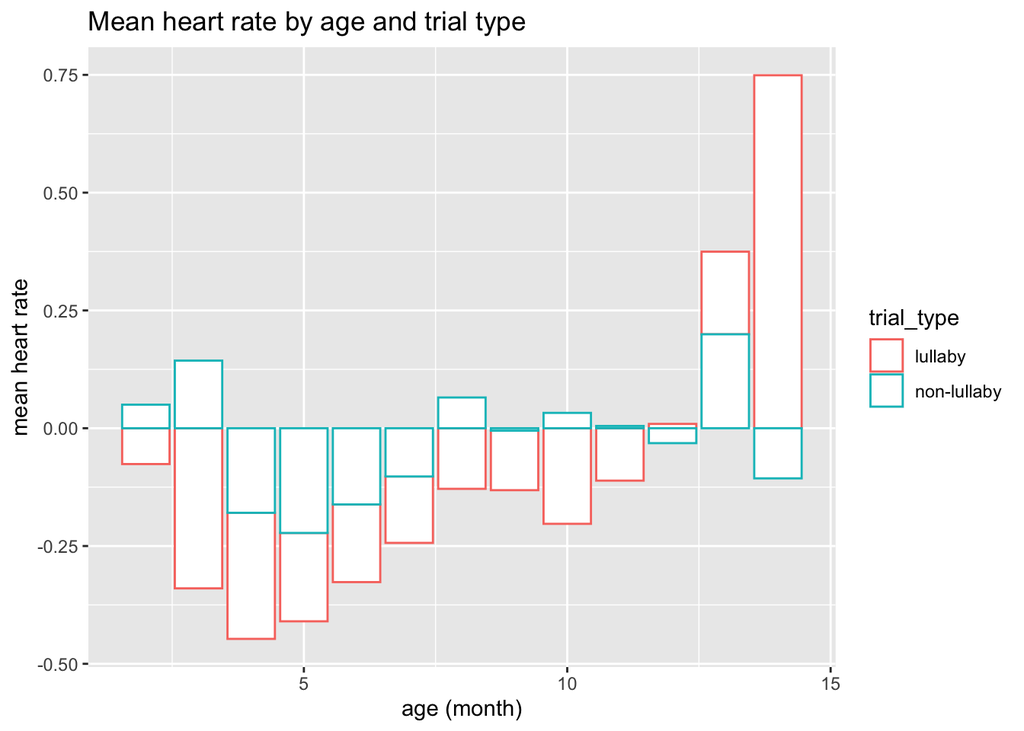

```r
ggplot(bb2021_by_age, mapping = aes(x = age_cat, y = age_mean, color = trial_type)) +
  geom_col(fill = "white") +
  ggtitle("Mean heart rate by age and trial type") +
  xlab("age (month)") +
  ylab("mean heart rate")
```

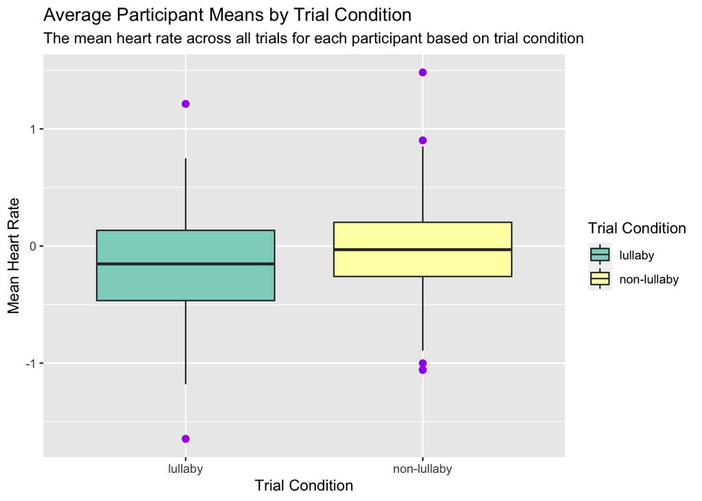

```r
# Bethany (outlier customization)
participant_means %>%
  ggplot(mapping = aes(x=trial_type, y=mean)) +
  geom_boxplot(outlier.colour = 'purple', outlier.size = 2, aes(fill=trial_type)) +
  scale_fill_brewer(palette = 'Set3', name='Trial Condition') +
  ggtitle(label='Average Participant Means by Trial Condition', subtitle = 'The mean heart rate across all trials for each participant based on trial condition') +
  xlab('Trial Condition') +
  ylab('Mean Heart Rate')
```